# Seaborn_cz1_zadania

#### **Skorzystaj z biblioteki seaborn i spróbuj odtworzyć przedstawione poniżej wykresy.**

##### Zbiór danych:

Do wizualizacji z wykorzystaniem biblioteki seaborn skorzystaj ze zbioru danych `Pokemon.csv`, który zawiera informację o 151 pokemonach z regionu Kanto.

```python
# Importujemy niezbędne biblioteki
import seaborn as sns
import matplotlib.pyplot as plt
import pandas as pd
%matplotlib inline
```

```python
# Ustawienie stylu wykresów (tło jasne)
sns.set_style('whitegrid')
```

```python
# Załadowanie zbioru 'Pokemon.csv' do zmiennej df. Prosze zwrócić uwagę na dodatkowe argumenty
# index_col=0 - ustalenie pierwszej kolumny jako kolumna indeksująca
# encoding='latin' - załadowanie
df = pd.read_csv('Pokemon.csv', index_col=0, encoding='latin')
```

```python
# Wypisanie 5 pierwszych rzędów zbioru wraz z nagłówkami
df.head()
```

| # | Name | Type 1 | Type 2 | Total | HP | Attack | Defense | Sp. Atk | Sp. Def | Speed | Stage | Legendary |
| --- | --- | --- | --- | --- | --- | --- | --- | --- | --- | --- | --- | --- |
| 1 | Bulbasaur | Grass | Poison | 318 | 45 | 49 | 49 | 65 | 65 | 45 | 1 | False |
| 2 | Ivysaur | Grass | Poison | 405 | 60 | 62 | 63 | 80 | 80 | 60 | 2 | False |
| 3 | Venusaur | Grass | Poison | 525 | 80 | 82 | 83 | 100 | 100 | 80 | 3 | False |
| 4 | Charmander | Fire | NaN | 309 | 39 | 52 | 43 | 60 | 50 | 65 | 1 | False |
| 5 | Charmeleon | Fire | NaN | 405 | 58 | 64 | 58 | 80 | 65 | 80 | 2 | False |

```python
# Tam gdzie nazwy kolumn mają spacje, zastąpimy je podkreślnikiem '_'
df.columns = [c.replace(' ', '_') for c in df.columns]
```

```python
df.head()
```

| # | Name | Type_1 | Type_2 | Total | HP | Attack | Defense | Sp._Atk | Sp._Def | Speed | Stage | Legendary |
| --- | --- | --- | --- | --- | --- | --- | --- | --- | --- | --- | --- | --- |
| 1 | Bulbasaur | Grass | Poison | 318 | 45 | 49 | 49 | 65 | 65 | 45 | 1 | False |
| 2 | Ivysaur | Grass | Poison | 405 | 60 | 62 | 63 | 80 | 80 | 60 | 2 | False |
| 3 | Venusaur | Grass | Poison | 525 | 80 | 82 | 83 | 100 | 100 | 80 | 3 | False |
| 4 | Charmander | Fire | NaN | 309 | 39 | 52 | 43 | 60 | 50 | 65 | 1 | False |
| 5 | Charmeleon | Fire | NaN | 405 | 58 | 64 | 58 | 80 | 65 | 80 | 2 | False |

# **Zadania do wykonania:**

**Przy użyciu biblioteki seaborn, poznanych wcześniej bibliotek (pandas, numpy) oraz zbioru Pokemon.csv spróbuj odtworzyć poniższe wykresy. Zwróć uwagę na detale - legendę, opisy osi, siatkę (grid), zakresy osi x i y, etc. Postaraj się nie używać biblioteki matplotlib**

** *Uwaga! Aby nie stracić widocznych przykładów, nie wywołuj ponownie pustej komórki zawierającej rozwiązanie.* **

## Zadanie 1 - Stwórz wykres punktowy (scatter plot)

https://seaborn.pydata.org/generated/seaborn.scatterplot.html

Wykres ma przedstawiać zależność ataku (Attack) od obrony (Defense) dla pokemonów mających wyłącznie jeden typ (kolumna Type 2 bez wartości) dla 3 róznych etapów ewolucji pokemonów (kolumna Stage).

- pogrupuj elementy względem ewolucji pokemona - skorzystaj z parametru 'hue'
- aby sprawdzić czy Type 2 ma wartość NaN, wykorzystaj funkcję isnull())
- na osi x przedstaw atak, a na osi y obronę pokemona
- przesuń legendę wykorzystując funkcję sns.move_legend() https://seaborn.pydata.org/generated/seaborn.move_legend.html
- dodaj tytuł, opisz oś x i y (możesz użyć matplotliba)

** *Uwaga! Aby nie stracić przykładu rozwiązania, nie wywołuj ponownie poniższej pustej komórki.* **

```python
#### Zad 1
## Tu umieść swoje rozwiązanie
```

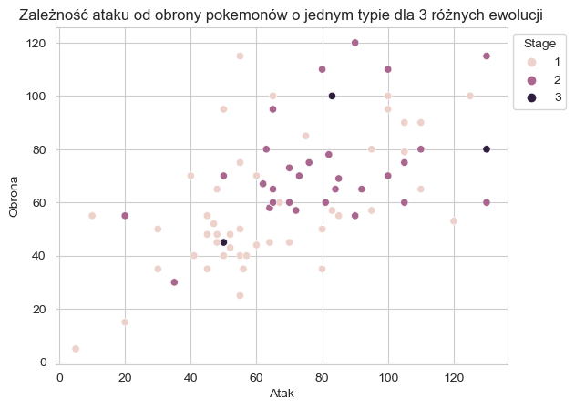

```python
# Nie uruchamiaj tej komórki
```

## Zadanie 2 - Stwórz wykres słupkowy (bar plot)

https://seaborn.pydata.org/generated/seaborn.barplot.html

Wykres słupkowy ma przedstawiać liczbę pokemonów, których podstawowym typem (Type 1) jest typ trawiasy (Grass), ognisty (Fire) lub wodny (Water).

- na początku odpowiednio przefiltruj dane, to znaczy wyciągnij informacje wyłacznie o wspomnianych trzech typach pokemonów
- następnie pogrupuj dane względem typu
- wyciągnij informację na temat ilości pokemonów dla każdego z typów
  - podpowiedź: dla ułatwienia zadania - jeśli używasz groupby() i count() - przekonwertuj serię danych na dataframe używając reset_index()
- ustaw kolor słupków zgodnie z typem pokemona - skorzystaj z argumentu *palette*
  - możesz użyć poniższego schematu kolorów

    pkmn_type_colors = ['#F08030','#78C850','#6890F0']
- ustaw etykietę osi x i y, nadaj wykresowi tytuł (możesz użyć matplotlib)

```python
#### Zad 2
## Tu umieść swoje rozwiązanie
```

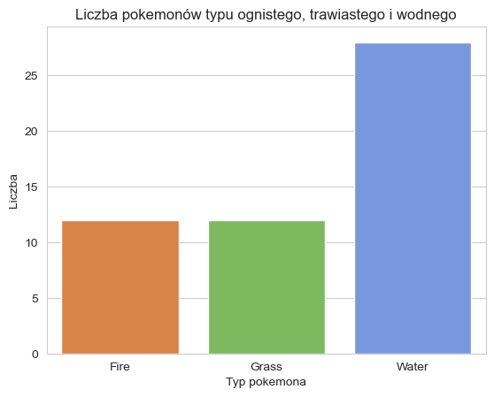

```python
# Nie uruchamiaj tej komórki
```

## Zadanie 3 - Stwórz wykres kołowy (pie chart)

Biblioteka seaborn nie ma dedykowanej funkcji służącej do stworzenia wykresu kołowego. Aby stworzyć wykres użyj biblioteki matplotlib: *plt.pie()* , jednak aby nadać schemat kolorów skorzystaj z funkcji:

```
sns.color_palette()
```

https://seaborn.pydata.org/generated/seaborn.color_palette.html#seaborn.color_palette

Wykres kołowy powinien przedstawić jaki procent pokemonów stanowią pokemony legendarne:

- zmień nazwy wartości kolumny "Legendary" z "False"/"True" na "Zwykły"/"Legendarny"
- wyświetl wartości procentowe na wykresie kołowym stosując parametr *autopct*
- nadaj wykresowi tytuł (możesz użyć matplotlib)

```python
#### Zad 3
## Tu umieść swoje rozwiązanie
```

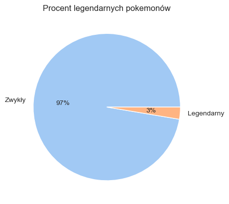

```python
# Nie uruchamiaj tej komórki
```

***Seaborn daje nam również możliwość tworzenia bardziej skomplikowanych wykresów i analiz.***

***Poniżej znajdziesz przykłady wykresów, które nie zostały wspomniane przy okazji omawiania biblioteki matplotlib wraz z wyjaśnieniami: box plot, joint plot, pair plot***

## Zadanie 4 - Stwórz wykres pudełkowy (box plot)

https://seaborn.pydata.org/generated/seaborn.boxplot.html

Wykres pudełkowy przedstawia rozkład wartości danych dla każdej grupy. Pozioma kreska na środku pudełka oznacza medianę, z kolei równoległe do mediany boki oznaczają kwartyle - dolny, czyli pierwszy kwartyl oraz górny czyli trzeci kwartyl.

(czym jest kwartyl -> https://pl.wikipedia.org/wiki/Kwartyl)

Wąsy poza boksami przedstawiają dolną i górną granicę danych. Pojedyncze punkty poza wąsami przedstawiają wartości odstające (outliers)

**Zadanie:** Przedstaw statystyki pokemonów w postaci wykresu pudełkowego **sns.boxplot()**. Wykorzystaj kolumnę HP, Attack oraz Defence (pamiętaj: do wyciągnięcia kolumn możesz użyć m.in. funkcji .loc lub .iloc)

- dodaj tytuł, opisz oś y - możesz skorzystać z biblioteki matplotlib
- zmień nazwy kolumn, aby oś x wyświetlała się jak na przedstawionym wykresie (podobnie jak w poprzednim wykresie, możesz skorzystać z .set_axis())

```python
#### Zad 4
## Tu umieść swoje rozwiązanie
```

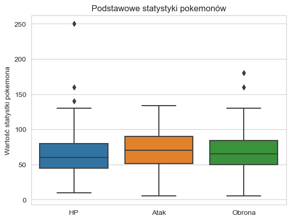

```python
# Nie uruchamiaj tej komórki
```

## Zadanie 5 - Stwórz wykres łączony (joint plot)

Wykres przedstawiający główną zależność dwóch zmiennych (x i y) oraz zależność opisującą główny wykres. W poniższym przykładzie, wykresem opisującym wykres punktowy jest wykres gęstości.

https://seaborn.pydata.org/generated/seaborn.jointplot.html

Przedstaw zależność wartości ataku (Attack) od obrony (Defense) przy rozróżnieniu pokemonów na legendarne i zwykłe (kolumna Legendary) używając funkcji **sns.jointplot()**

```python
#### Zad 5
## Tu umieść swoje rozwiązanie
```

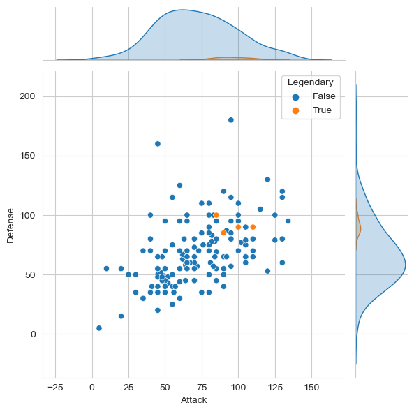

```python
# Nie uruchamiaj tej komórki
```

## Zadanie 6 - Stwórz macierz korelacji (pair plot)

Wykres przedstawiający macierz korelacji - wskazuje na korelację dla odpowiednich par zmiennych losowych. Dla tej samej pary (Attack-Attack, Defense-Defense ...) przedstawione są histogramy, czyli częstości występowania danej cechy (na osi x widać wartości cechy, na y częstość występowania). Wykresy punktowe standardowo przedstawiają zależność jednej cechy od drugiej.

https://seaborn.pydata.org/generated/seaborn.pairplot.html

Stwórz macierz korelacji dla Ataku, Obrony i Szybkości pokemonów:

- wyciągnij odpowiednie kolumny przy pomocy funkcji .loc()
- zwizualizuj wyżej wymienione statystyki przy pomocy **sns.pairplot()**

```python
#### Zad 6
## Tu umieść swoje rozwiązanie
```

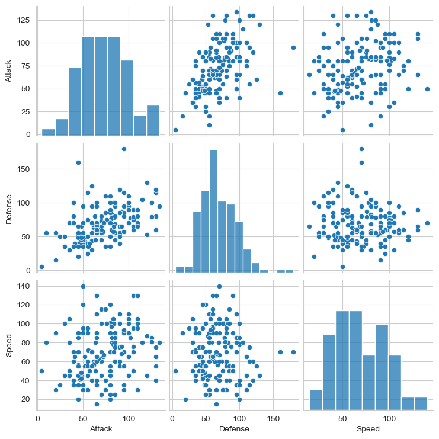

```python
# Nie uruchamiaj tej komórki
```

**Przyjrzyj się powyższemu wykresowi macierzy korelacji i odpowiedz na pytania:**

1. Które cechy są od siebie zależne (wraz ze wzrostem jednej wzrasta druga lub na odwrót)?
2. Jaką najczęściej pojawiającą się wartość obrony pokemona (Defense) wskazuje środkowy histogram?
3. Czy na histogramie przedstawiającym atak pokemona najczęściej pojawiają się wartości skrajne? Uzasadnij odpowiedź.